# Stepwise Regression with Negatively Correlated Covariates

## Step3

### Algorithm Idea

Step3 does everything that Step2 does, but it also considers recursing on the pairwise negatively correlated covariates, i.e. the blocks of Step2, and considering anything highly correlated with them and then anything highly correlated with those, etc until it reaches a block size of `max_block_size`. Additionally, Step3 with a `max_block_size` of 2 is equivalent to Step2. The depth used in this report is set at 3, so the algorithm will, at most, consider including three covariates at a time. This choice was arbitrary.

What is classified as a highly correlated variable for the purposes of recursion are set by the two parameters `recursive_cor_positive_cutoff` and `recursive_cor_negative_cutoff`. In this report 0.5 and -0.5 was used for `recursive_cor_positive_cutoff` and `recursive_cor_negative_cutoff`, respectively. The choice of 0.5 and -0.5 was arbitrary.

- Let $\land$ represent logical $\text{AND}$
- Let $\lor$ represent logical $\text{OR}$
- Let $\text{CC}$ be a short-form for `cor_cutoff`
- Let $\text{RCN}$ be a short-form for `recursive_cor_negative_cutoff`
- Let $\text{RCP}$ be a short-form for `recursive_cor_positive_cutoff`
- Let $r(x_1,x_2)$ denote the sample correlation between $x_1$ and $x_2$
- Let $S_1$ denote the set of covariates
- Then $S_2$ denoting the set of highly negatively correlated pairs $(x_1,x_2)$ is defined as
  $$S_2 = \{(x_1, x_2) \, | \, x_1 \in S_1 \land x_2 \in S_1 \land x_1 \neq x_2 \land r(x_1,x_2) < \text{CC} \}$$
- Then $S_3$ denoting the set of triples $(x_1,x_2,x_3)$ is defined as
  $$S_3 = \{ (x_1, x_2, x_3) \, | \, (x_1,x_2) \in S_2 \, \land x_3 \, \in S_1 \, \land \, x_3 \notin (x_1, x_2) \land \left(\text{block } x_1 \, x_2 \, x_3 \right) \}$$
  where
  $$\text{block } x \, y \, z = (r(x,z) < \text{RCN}) \lor (r(x,z) > \text{RCP}) \lor (r(y,z) < \text{RCN}) \lor (r(y,z) > \text{RCP})$$
- Likewise this pattern continues
- Then, in the genral case, $S_n$ denoting the set of length $n$, $(x_1,x_2, \dots, x_n)$ is defined as
  $$S_n = \{ (x_1, \dots, x_n) \, \, | \, \, (x_1, \dots, x_{n-1}) \in S_{n-1} \, \land \, x_n \in S_1 \, \land \, x_n \notin (x_1, \dots, x_{n-1}) \, \land \, \left(\text{block2 } (x_1, \dots, x_{n-1}) \, x_n \right) \}$$
  where
  $$\text{block2 } D \, c = \exists a, b \in D \, | \, a \neq b \land \text{block } a \, b \, c$$

### Pseudocode Changes from Step2

The core of the algorithm is the same as Step2, except for computing pairs and adding or removing pairs to current formula. This is because pairs are now generalized to lists of size $\geq 2$. In the case of adding or removing pairs to current formula, Step3 appends the objects in lists to the current formula if none are currently in the current formula and it removes them if all are currently in the current formula.

### Time and Space Complexity vs Step

With a terrible choice of cutoff parameters (e.g. correlation < 1 or > -1) and unlimited recursion depth, Step3 will preform all subsets regression. All subsets regression has an exponential time complexity in the number of covariates.

The worst case space and time complexity for a `max_block_size` of $\text{mbs}$ is $\mathcal O\left( p ^ {(\text{mbs}-1)}\right)$ times that of Step. With proper choices of cutoffs the time and space complexity is expected to be within a constant of Step.

Note that the expected proportional increase in running time could be computed before running any simulations for any given data set and algorithm parameters. A possible future improvement could involve the algorithm guaranteeing similar performance to Step by tuning the algorithm parameters for a given data set.

# Simulations

## Linear model

- $\mathbf Y = \beta_0 + \beta_1 \mathbf X_1 + \beta_2 \mathbf X_2 + \cdots + \epsilon$
- $\mathbf X_i$ are correlated, centred random normal variables
- Intercept ($\beta_0 = 9$)
- $\epsilon \sim \mathcal N(\mu = 0, \sigma = 1)$
- 1000 Simulations

## Generating Correlated Centred Random Normal Variables

The variables are generated according the the formula
$$\mathbf X = \mathbf{C Z}$$
This generates a vector of correlated random normal variables $\mathbf X \sim \mathcal N(\boldsymbol \mu = 0, \mathbf \Sigma)$

where $\mathbf C$ is a $p \times p$ matrix that can be solved from the given covariate matrix, $\boldsymbol \Sigma$, such that

$$\boldsymbol \Sigma = \mathbf {C C^T} =
\begin{bmatrix}
\sigma_1^2 & \sigma_{12} & \cdots & \sigma_{1p} \\
\sigma_{21} & \sigma_2^2 & \cdots & \sigma_{2p} \\
\vdots & \vdots & \ddots & \vdots \\
\sigma_{1p} & \sigma_{2p} & \cdots & \sigma_p^2
\end{bmatrix}$$

$\mathbf C$ is found using [Cholesky decomposition](https://en.wikipedia.org/wiki/Cholesky_decomposition)

Where $\mathbf Z$ is a vector of random normal variables
$$\mathbf Z = \begin{bmatrix} z_1 \\ z_2 \\ \vdots \\ z_p \end{bmatrix}$$
Where $Z_i \sim \mathcal N(\mu = 0, \sigma = 1)$

## Model 1 : Two negatively correlated

This model is designed to show the advantage of Step2 over Step
$$\boldsymbol{\Sigma} =\begin{bmatrix}
1 &-0.8 & 0 & 0 & 0 & 0 \\
-0.8& 1 & 0 & 0 & 0 & 0 \\
0 & 0 & 1 & 0 & 0 & 0 \\
0 & 0 & 0 & 1 & 0 & 0 \\
0 & 0 & 0 & 0 & 1 & 0 \\
0 & 0 & 0 & 0 & 0 & 1
\end{bmatrix} \hspace{10pt}
\hspace{20pt}
\boldsymbol{\beta} = \begin{bmatrix} 1 \\ 1 \\ 0 \\ 0 \\ 0 \\ 0 \end{bmatrix}$$

$n$ = 100

## Model 2: Three Negatively Correlated

This model is designed to show the advantage of Step3 over Step2 and Step

$$\boldsymbol{\Sigma} = \begin{bmatrix}
1 & -0.8 & 0.25 & 0 & 0 & 0 & 0 & 0 & 0 & 0 \\
-0.8 & 1 & -0.75 & 0 & 0& 0 & 0 & 0 & 0 & 0 \\
0.25 & -0.75 & 1 & 0 & 0& 0 & 0 & 0 & 0 & 0 \\
0 & 0 & 0 & 1 & 0& 0 & 0 & 0 & 0 & 0 \\
0 & 0 & 0 & 0 & 1 & 0 & 0 & 0 & 0 & 0 \\
0 & 0 & 0 & 0 & 0 & 1 & 0 & 0 & 0 & 0 \\
0 & 0 & 0 & 0 & 0 & 0 & 1 & 0 & 0 & 0 \\
0 & 0 & 0 & 0 & 0 & 0 & 0 & 1 & 0 & 0 \\
0 & 0 & 0 & 0 & 0 & 0 & 0 & 0 & 1 & 0 \\
0 & 0 & 0 & 0 & 0 & 0 & 0 & 0 & 0 & 1 \\
\end{bmatrix}
\hspace{10pt}
\hspace{20pt}
\boldsymbol{\beta} =
\begin{bmatrix} 1 \\ 1 \\ 1 \\ 0 \\ 0 \\ 0 \\ 0 \\ 0 \\ 0 \\ 0
\end{bmatrix}$$
$n$ = 100

## Model 3 : Big p

This model is designed to show the advantages of Step2 and Step3 over Step when $p >> n$. Note the covariates V6 through V100 are independent and do not contribute to the response ($\beta_i = 0$ for $i \in [6..100]$).

$$\boldsymbol \Sigma = \begin{bmatrix}
1 & -0.8 & 0.25 & 0 & 0 & 0 &\cdots & 0\\
-0.8& 1 & -0.5 & 0 & 0 & 0 & \cdots & 0 \\
0.25& -0.5 & 1 & 0 & 0 & 0 & \cdots & 0\\
0 & 0 & 0 & 1 & -0.75 & 0 & \cdots & 0\\
0 & 0 & 0 & -0.75 & 1 & 0 & \cdots & 0\\
0 & 0 & 0 & 0 & 0 & 1 &\cdots & 0\\
\vdots & \vdots & \vdots & \vdots & \vdots & \vdots & \ddots & \vdots \\
0 & 0 & 0 & 0 & 0 & 0 & \cdots & 1
\end{bmatrix}
\hspace{10pt} \hspace{20pt}
\boldsymbol \beta =
\begin{bmatrix} 1 \\ 1 \\ 1 \\ 1 \\ 1 \\ 0 \\ \vdots \\ 0 \\ \end{bmatrix}$$
$n$ = 50

# Results

## Model 1 : Two Negatively Correlated

In this case Step3 did not end up selecting any more covariates to add to its block inclusion via its recursion, so it was identical to Step2. They were identical since only two covariates were high negatively correlated ($X_1$ and $X_2$) and neither $X_1$ nor $X_2$ were highly correlated with any other covariates. This meant that Step2 and Step3 considered including $X_1$ and $X_2$ in the same step, but did not consider adding any other variables in the same step.

Both Step2 and Step3 outperformed Step, since Step often ($\approx 30\%$) selected no covariates to include in the model (i.e. the intercept only model). This is due to the highly negative sample correlation ($r \approx -0.8$) between $X_1$ and $X_2$.

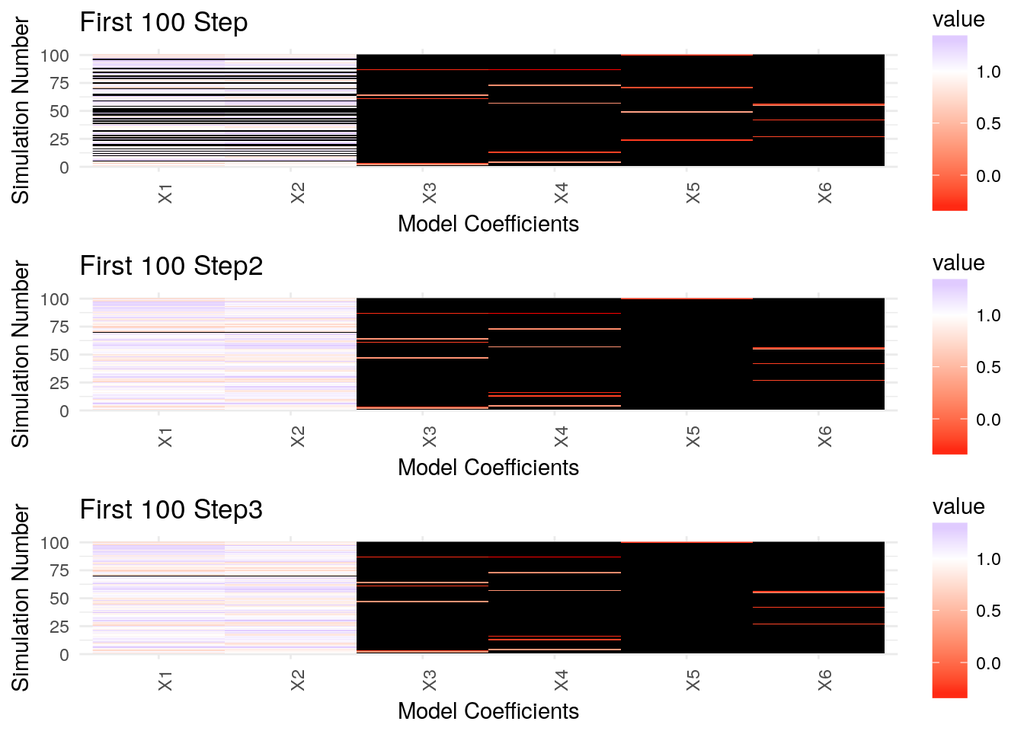

Here the heat map for the first 100 simulations and the values of the model coefficients are shown. Note that NA values are shown as black, meaning that coefficient was not selected in that simulation. Step often misses both X1 and X2, while Step2 and Step3 nearly always include both of these variables.

% Simulations Including Covariates

|  | Step | Step2 | Step3 |
| --- | --- | --- | --- |
| X1 | 0.659 | 0.998 | 0.998 |
| X2 | 0.659 | 0.998 | 0.998 |
| X3 | 0.035 | 0.037 | 0.037 |
| X4 | 0.040 | 0.039 | 0.039 |
| X5 | 0.042 | 0.044 | 0.044 |
| X6 | 0.035 | 0.036 | 0.036 |

Table 1 shows the proportion of times that each algorithm selected a given covariate. Step did not select X1 or X2 over a third of the time. Step2 and Step3 nearly always select X1 and X2.

In the appendix is the proportion of times that each algorithm selected the correct model.

Fitted Coefficients Bias

|  | Step | Step2 | Step3 |
| --- | --- | --- | --- |
| (Intercept) | -0.007 | -0.004 | -0.004 |
| X1 | -0.319 | 0.002 | 0.002 |
| X2 | -0.321 | 0.001 | 0.001 |
| X3 | 0.001 | 0.001 | 0.001 |
| X4 | -0.002 | -0.003 | -0.003 |
| X5 | -0.002 | -0.002 | -0.002 |
| X6 | 0.002 | 0.002 | 0.002 |

Fitted Coefficients Variance

|  | Step | Step2 | Step3 |
| --- | --- | --- | --- |
| (Intercept) | 0.012 | 0.011 | 0.011 |
| X1 | 0.258 | 0.031 | 0.031 |
| X2 | 0.256 | 0.030 | 0.030 |
| X3 | 0.002 | 0.002 | 0.002 |
| X4 | 0.003 | 0.003 | 0.003 |
| X5 | 0.003 | 0.003 | 0.003 |
| X6 | 0.002 | 0.002 | 0.002 |

The variance of the fitted values for X1 and X2, shown in Table 3 is also reduced since Step included X1 and X2 about 60% of the time

Inclusion Order for Step, Step2, Step3 Respectively

| Order Step | # Step |
| --- | --- |
| \|\| | 304 |
| X1 \| X2 \|\| | 289 |
| X2 \| X1 \|\| | 265 |
| X2 \| X1 \| X4 \|\| | 14 |
| X1 \| X2 \| X5 \|\| | 12 |

| Order Step2 | # Step2 |
| --- | --- |
| X1X2 \|\| | 852 |
| X1X2 \| X5 \|\| | 39 |
| X1X2 \| X3 \|\| | 35 |
| X1X2 \| X4 \|\| | 31 |
| X1X2 \| X6 \|\| | 31 |

| Order Step3 | # Step3 |
| --- | --- |
| X1X2 \|\| | 852 |
| X1X2 \| X5 \|\| | 39 |
| X1X2 \| X3 \|\| | 35 |
| X1X2 \| X4 \|\| | 31 |
| X1X2 \| X6 \|\| | 31 |

Table 4 shows the 5 most commonly occuring orders that each variable was included, by each stepwise algorithm. The full tables are available in the appendix. Note that the character | delineates the steps of the selection algorithm and || denotes the termination of the selection algorithm.

For example, || denotes the algorithm terminated without selecting any variables, while X1X2 | X3 || means the algorithm selected both X1 and X2 in the first step, X3 in the second step and then terminated.

Step2 and Step3 are identical, as explained at the start of the section. Step did not select any variables over a quarter of the time. In nearly all cases, Step2 and Step3 selected X1 and X2 together. It is ability to include highly negatively correlated covariates together that makes Step2 and Step3 ideal in this type of case with high pairwise negative correlations.

$$\begin{bmatrix}
X & -0.89/-0.64 & -0.3/0.33 & -0.31/0.28 & -0.29/0.33 & -0.32/0.33 \\ -0.89/-0.64 & X & -0.26/0.3 & -0.35/0.37 & -0.31/0.28 & -0.27/0.3 \\ -0.3/0.33 & -0.26/0.3 & X & -0.31/0.27 & -0.29/0.28 & -0.31/0.33 \\ -0.31/0.28 & -0.35/0.37 & -0.31/0.27 & X & -0.29/0.3 & -0.27/0.33 \\ -0.29/0.33 & -0.31/0.28 & -0.29/0.28 & -0.29/0.3 & X & -0.32/0.32 \\ -0.32/0.33 & -0.27/0.3 & -0.31/0.33 & -0.27/0.33 & -0.32/0.32 & X \end{bmatrix}$$

Test SSE

|  | Min | Max | Mean | Median |
| --- | --- | --- | --- | --- |
| Step | 66.767 | 205.301 | 117.903 | 114.020 |
| Step2 | 66.098 | 169.813 | 104.488 | 103.787 |
| Step3 | 66.098 | 169.813 | 104.488 | 103.787 |

Training SSE

|  | Min | Max | Mean | Median |
| --- | --- | --- | --- | --- |
| Step | 62.028 | 197.897 | 108.396 | 103.517 |
| Step2 | 59.685 | 140.377 | 96.765 | 96.000 |
| Step3 | 59.685 | 140.377 | 96.765 | 96.000 |

Table 5 and Table 6 show the test and training SSE from each algorithm. Step2 and Step3 are, again, identical. Step2 and Step3 reduced the training SSE and test SSE compared to Step by 10.7% and 11.4%, respectively.

Boxplots of test and training SSE are located in the appendix

## Model 2 : Three Negatively Correlated

In addition to examing singles, like Step, Step2 and Step3 would examine pairs of X1, X2 and X3. Finally Step3 would additionally consider adding X1, X2 and X3 all together. This results in Step2 having better results than Step and Step3 having better results than Step2.

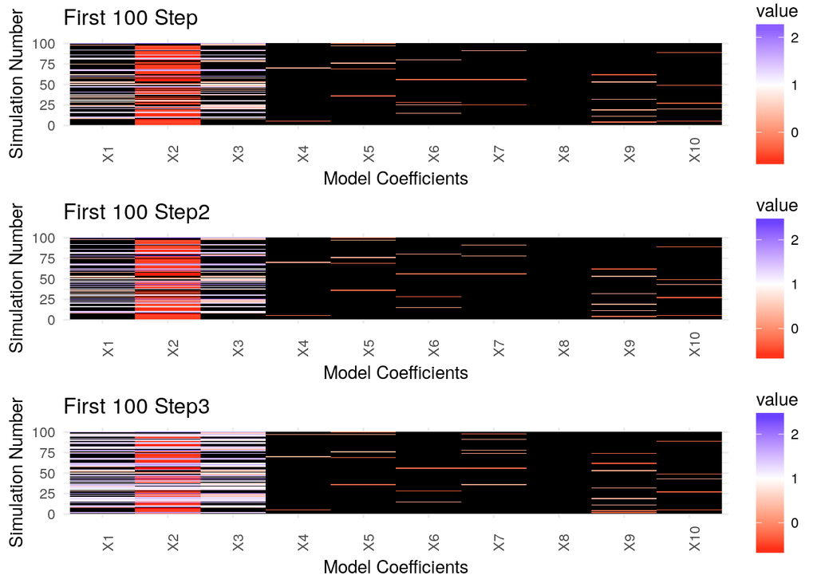

Examining the heat map of fitted coefficients, all algorithms have difficulty selecting all the correct covariates. This is an especially difficult correlation structure. However Step3 does a considerably better job at selecting all of X1, X2 and X3 compared to Step and Step2.

% Simulations Including Covariates

|  | Step | Step2 | Step3 |
| --- | --- | --- | --- |
| X1 | 0.226 | 0.273 | 0.566 |
| X2 | 0.778 | 0.853 | 0.870 |
| X3 | 0.317 | 0.341 | 0.631 |
| X4 | 0.034 | 0.034 | 0.039 |
| X5 | 0.032 | 0.031 | 0.031 |
| X6 | 0.036 | 0.035 | 0.035 |
| X7 | 0.038 | 0.038 | 0.041 |
| X8 | 0.025 | 0.026 | 0.029 |
| X9 | 0.033 | 0.033 | 0.035 |
| X10 | 0.040 | 0.042 | 0.044 |

Table 7 shows the proportion of times that each algorithm selected a given covariate. Step had very poor performance in selecting X1 and X3, about a fifth and a third of the time respectively. Step2 offered slght improvements with these two variables, but Step3 showed a marked improvement selecting both X1 and X3 compared to Step or Step2.

It is also worth noting that Step2 and Step3 performed better in selecting X2 over Step. This suggests that X2 was not always significant by itself.

In the appendix is the proportion of times that each algorithm selected the correct model.

Fitted Coefficients Bias

|  | Step | Step2 | Step3 |
| --- | --- | --- | --- |
| (Intercept) | 0.000 | 0.000 | -0.001 |
| X1 | -0.789 | -0.705 | -0.326 |
| X2 | -1.164 | -1.049 | -0.479 |
| X3 | -0.731 | -0.661 | -0.306 |
| X4 | 0.000 | 0.000 | 0.001 |
| X5 | 0.002 | 0.002 | 0.001 |
| X6 | 0.000 | -0.001 | -0.001 |
| X7 | -0.001 | -0.001 | -0.001 |
| X8 | -0.001 | -0.001 | -0.001 |
| X9 | 0.004 | 0.004 | 0.003 |
| X10 | -0.003 | -0.003 | -0.004 |

Fitted Coefficients Variance

|  | Step | Step2 | Step3 |
| --- | --- | --- | --- |
| (Intercept) | 0.011 | 0.010 | 0.010 |
| X1 | 0.206 | 0.284 | 0.416 |
| X2 | 0.494 | 0.703 | 0.906 |
| X3 | 0.223 | 0.294 | 0.366 |
| X4 | 0.002 | 0.002 | 0.003 |
| X5 | 0.002 | 0.002 | 0.002 |
| X6 | 0.002 | 0.002 | 0.002 |
| X7 | 0.002 | 0.002 | 0.002 |
| X8 | 0.002 | 0.002 | 0.002 |
| X9 | 0.002 | 0.002 | 0.003 |
| X10 | 0.003 | 0.003 | 0.003 |

Step2 reduces the bias of X1, X2 and X3 (Table 8), but suffers greater fitted coefficient variance compared to Step (Table 9). Step3 further reduces the bias of X1, X2 and X3, but suffers greater fitted coefficient variance compared to Step2. The increase in variance is most likely due to the fact that the proportion that X1 and X3 are selected approaches 50% with Step3 (Table 7). Additionally the proportion that Step3 selected at least the correct covariates (Table 21), or the correct model (Table 20) is far closer to 50% compared to Step. These two tables, Table 20 and Table 21, are in the appendix.

Inclusion Order for Step, Step2, Step3 Respectively

| Order Step | # Step |
| --- | --- |
| X2 \|\| | 498 |
| X3 \|\| | 98 |
| X3 \| X1 \| X2 \|\| | 74 |
| X1 \|\| | 40 |
| X3 \| X1 \|\| | 31 |
| X2 \| X6 \|\| | 19 |
| X2 \| X9 \|\| | 19 |
| X2 \| X4 \|\| | 18 |
| X1 \| X3 \| X2 \|\| | 17 |
| X2 \| X10 \|\| | 17 |

| Order Step2 | # Step2 |
| --- | --- |
| X2 \|\| | 498 |
| X3 \| X1X2 \|\| | 94 |
| X3 \|\| | 63 |
| X1 \| X2X3 \|\| | 32 |
| X2X3 \| X1 \|\| | 30 |
| X3 \| X1 \|\| | 26 |
| X1 \|\| | 22 |
| X2 \| X6 \|\| | 19 |
| X2 \| X9 \|\| | 19 |
| X2 \| X4 \|\| | 18 |

| Order Step3 | # Step3 |
| --- | --- |
| X1X2X3 \|\| | 382 |
| X2 \|\| | 271 |
| X3 \|\| | 63 |
| X1X2X3 \| X10 \|\| | 23 |
| X1X2X3 \| X7 \|\| | 23 |
| X1 \|\| | 22 |
| X1X2X3 \| X4 \|\| | 19 |
| X3 \| X1 \|\| | 18 |
| X1X2X3 \| X6 \|\| | 17 |
| X2X3 \|\| | 13 |

In Table 10, Step3 shows its recursive ability here by including X1, X2 and X3 together in one single step.

$$\begin{psmallmatrix}
X & -0.89/-0.61 & -0.05/0.5 & -0.31/0.35 & -0.32/0.33 & -0.31/0.33 & -0.32/0.26 & -0.33/0.29 & -0.32/0.32 & -0.34/0.32 \\ -0.89/-0.61 & X & -0.85/-0.58 & -0.38/0.37 & -0.36/0.34 & -0.3/0.33 & -0.28/0.25 & -0.27/0.33 & -0.35/0.31 & -0.32/0.3 \\ -0.05/0.5 & -0.85/-0.58 & X & -0.34/0.32 & -0.38/0.31 & -0.3/0.32 & -0.34/0.32 & -0.3/0.32 & -0.3/0.28 & -0.36/0.27 \\ -0.31/0.35 & -0.38/0.37 & -0.34/0.32 & X & -0.35/0.29 & -0.26/0.35 & -0.32/0.27 & -0.29/0.35 & -0.31/0.36 & -0.31/0.29 \\ -0.32/0.33 & -0.36/0.34 & -0.38/0.31 & -0.35/0.29 & X & -0.28/0.31 & -0.32/0.32 & -0.29/0.31 & -0.34/0.36 & -0.34/0.31 \\ -0.31/0.33 & -0.3/0.33 & -0.3/0.32 & -0.26/0.35 & -0.28/0.31 & X & -0.31/0.36 & -0.35/0.27 & -0.31/0.28 & -0.3/0.31 \\ -0.32/0.26 & -0.28/0.25 & -0.34/0.32 & -0.32/0.27 & -0.32/0.32 & -0.31/0.36 & X & -0.31/0.27 & -0.28/0.29 & -0.3/0.29 \\ -0.33/0.29 & -0.27/0.33 & -0.3/0.32 & -0.29/0.35 & -0.29/0.31 & -0.35/0.27 & -0.31/0.27 & X & -0.34/0.34 & -0.31/0.27 \\ -0.32/0.32 & -0.35/0.31 & -0.3/0.28 & -0.31/0.36 & -0.34/0.36 & -0.31/0.28 & -0.28/0.29 & -0.34/0.34 & X & -0.31/0.29 \\ -0.34/0.32 & -0.32/0.3 & -0.36/0.27 & -0.31/0.29 & -0.34/0.31 & -0.3/0.31 & -0.3/0.29 & -0.31/0.27 & -0.31/0.29 & X \end{psmallmatrix}$$

Examining the sample correlation matrix, shown above, Step3 always had the option to include X1, X2 and X3 together.

Test SSE

|  | Min | Max | Mean | Median |
| --- | --- | --- | --- | --- |
| Step | 68.55 | 171.91 | 113.804 | 112.274 |
| Step2 | 68.55 | 171.91 | 112.838 | 111.249 |
| Step3 | 66.98 | 171.91 | 110.119 | 108.872 |

Training SSE

|  | Min | Max | Mean | Median |
| --- | --- | --- | --- | --- |
| Step | 56.453 | 167.015 | 102.996 | 102.008 |
| Step2 | 56.453 | 167.015 | 102.082 | 101.120 |
| Step3 | 56.453 | 143.900 | 97.779 | 96.817 |

As evidenced by Table 11 and Table 12, Step2 and Step had similar performance. Step2 had only slightly better test and training SSE than Step. The similar performance, between Step and Step2, is most likely due to the complex correlation structure of the covariates. Step2 is only designed to handle high levels of correlation between 2 covariates at a time, but the correlation structure here involves 3 covariates (X1, X2 and X3), so Step2’s performance is less than optimal. Step3, being designed to handle complex correlation structures with its recursive ability, improved upon the performance of Step and Step2.

Step3 reduced the training SSE and test SSE compared to Step by 5.1% and 3.2%, respectively.

Boxplots test and training SSE located in appendix

## Model 3 : Big p

In this simulation $p >> n$ and the curse of dimensionality is present in the results

% Simulations that Selected Correct Model

|  | x |
| --- | --- |
| Step | 0.000 |
| Step2 | 0.001 |
| Step3 | 0.001 |

There was so much noise that Step2 and Step3 selected the correct model only once and Step never selected it (Table 13).

% Simulations Selected at Minimum All Correct Covariates

|  | x |
| --- | --- |
| Step | 0.188 |
| Step2 | 0.817 |
| Step3 | 0.852 |

When judging algorithms on including at least the covariates of the correct model, Step3 did the best followed by Step2 and then Step (Table 14).

Test SSE

|  | Min | Max | Mean | Median |
| --- | --- | --- | --- | --- |
| Step | 66.55 | 1198.447 | 276.442 | 252.603 |
| Step2 | 39.07 | 884.075 | 226.345 | 210.094 |
| Step3 | 39.07 | 884.075 | 222.081 | 207.934 |

Training SSE

|  | Min | Max | Mean | Median |
| --- | --- | --- | --- | --- |
| Step | 0 | 115.590 | 7.046 | 0 |
| Step2 | 0 | 75.324 | 3.882 | 0 |
| Step3 | 0 | 75.324 | 3.660 | 0 |

Table 15 and 16 show the test and training SSE results. The median value of 0 for training SSE is not surprising, since it is easy to fit a perfect training model in the case of $p >> n$.

Step2 reduced the training SSE and test SSE compared to Step by 44.9% and 18.1%, respectively.

Step3 reduced the training SSE and test SSE compared to Step by 48.1% and 19.7%, respectively.

Boxplots of test and training SSE are located in the appendix

# Conclusion

Step2 and Step3 offer improvements to the traditional stepwise algorithm in the case of highly negatively correlated covariates, in terms of model fit. They can suffer from longer runtimes, especially when their algorithm parameters are chosen without regard for runtime.

# Appendix

## Future Inquiries

- A general recommendation for setting the algorithm parameters of Step2 or Step3
- Using crossvalidation to set the algorithm parameters
- Avoiding algorithm parameters choices that cause the asymptotic runtime to become greater than the traditional stepwise selection algorithm

## Additional Tables & Plots

### Model 1

% Simulations that Selected Correct Model

|  | x |
| --- | --- |
| Step | 0.554 |
| Step2 | 0.852 |
| Step3 | 0.852 |

% Simulations Selected at Minimum All Correct Covariates

|  | x |
| --- | --- |
| Step | 0.659 |
| Step2 | 0.998 |
| Step3 | 0.998 |

Inclusion Order for Step, Step2, Step3 Respectively

| Order Step | # Step |
| --- | --- |
| \|\| | 304 |
| X1 \| X2 \|\| | 289 |
| X2 \| X1 \|\| | 265 |
| X2 \| X1 \| X4 \|\| | 14 |
| X1 \| X2 \| X5 \|\| | 12 |
| X2 \| X1 \| X3 \|\| | 12 |
| X2 \| X1 \| X5 \|\| | 11 |
| X5 \|\| | 11 |
| X2 \| X1 \| X6 \|\| | 10 |
| X6 \|\| | 9 |
| X1 \| X2 \| X3 \|\| | 8 |
| X4 \|\| | 8 |
| X3 \|\| | 7 |
| X1 \| X2 \| X6 \|\| | 6 |
| X1 \| X2 \| X4 \|\| | 4 |
| X5 \| X2 \| X1 \|\| | 4 |
| X3 \| X2 \| X1 \|\| | 3 |
| X4 \| X1 \| X2 \|\| | 3 |
| X4 \| X2 \| X1 \|\| | 3 |
| X6 \| X1 \| X2 \|\| | 3 |
| X3 \| X1 \| X2 \|\| | 2 |
| X6 \| X2 \| X1 \|\| | 2 |
| X1 \| X2 \| X4 \| X5 \|\| | 1 |
| X1 \| X2 \| X4 \| X6 \|\| | 1 |
| X2 \| X1 \| X4 \| X6 \|\| | 1 |
| X3 \| X1 \| X2 \| X5 \|\| | 1 |
| X3 \| X6 \|\| | 1 |
| X4 \| X2 \| X1 \| X5 \|\| | 1 |
| X4 \| X3 \| X1 \| X2 \|\| | 1 |
| X4 \| X5 \| X2 \| X1 \|\| | 1 |
| X6 \| X2 \| X1 \| X4 \|\| | 1 |
| X6 \| X4 \|\| | 1 |

| Order Step2 | # Step2 |
| --- | --- |
| X1X2 \|\| | 852 |
| X1X2 \| X5 \|\| | 39 |
| X1X2 \| X3 \|\| | 35 |
| X1X2 \| X4 \|\| | 31 |
| X1X2 \| X6 \|\| | 31 |
| \|\| | 2 |
| X1X2 \| X4 \| X6 \|\| | 2 |
| X1X2 \| X5 \| X4 \|\| | 2 |
| X1X2 \| X6 \| X4 \|\| | 2 |
| X1X2 \| X3 \| X5 \|\| | 1 |
| X1X2 \| X4 \| X3 \|\| | 1 |
| X1X2 \| X4 \| X5 \|\| | 1 |
| X1X2 \| X5 \| X6 \|\| | 1 |

| Order Step3 | # Step3 |
| --- | --- |
| X1X2 \|\| | 852 |
| X1X2 \| X5 \|\| | 39 |
| X1X2 \| X3 \|\| | 35 |
| X1X2 \| X4 \|\| | 31 |
| X1X2 \| X6 \|\| | 31 |
| \|\| | 2 |
| X1X2 \| X4 \| X6 \|\| | 2 |
| X1X2 \| X5 \| X4 \|\| | 2 |
| X1X2 \| X6 \| X4 \|\| | 2 |
| X1X2 \| X3 \| X5 \|\| | 1 |
| X1X2 \| X4 \| X3 \|\| | 1 |
| X1X2 \| X4 \| X5 \|\| | 1 |
| X1X2 \| X5 \| X6 \|\| | 1 |

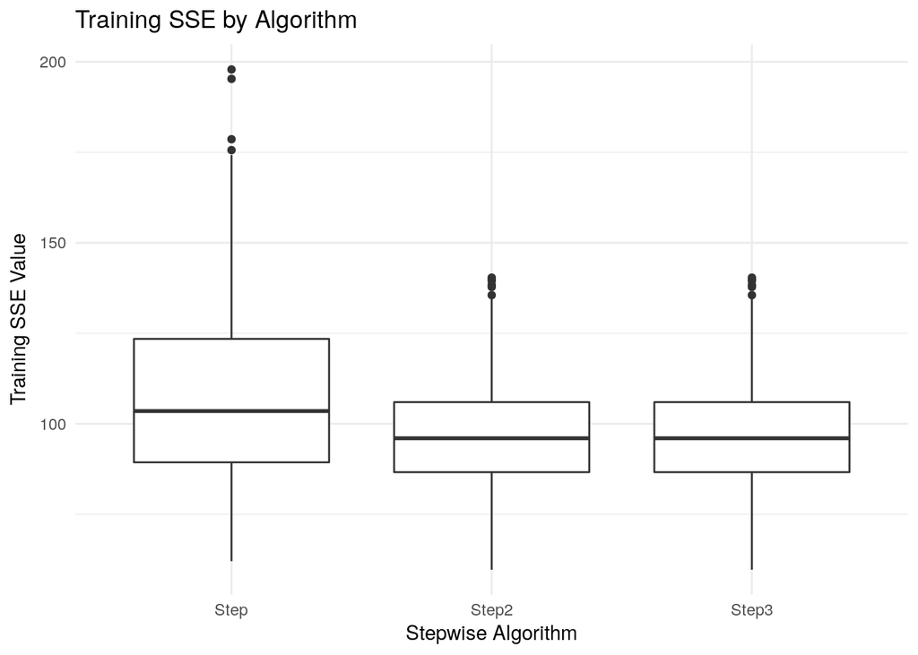

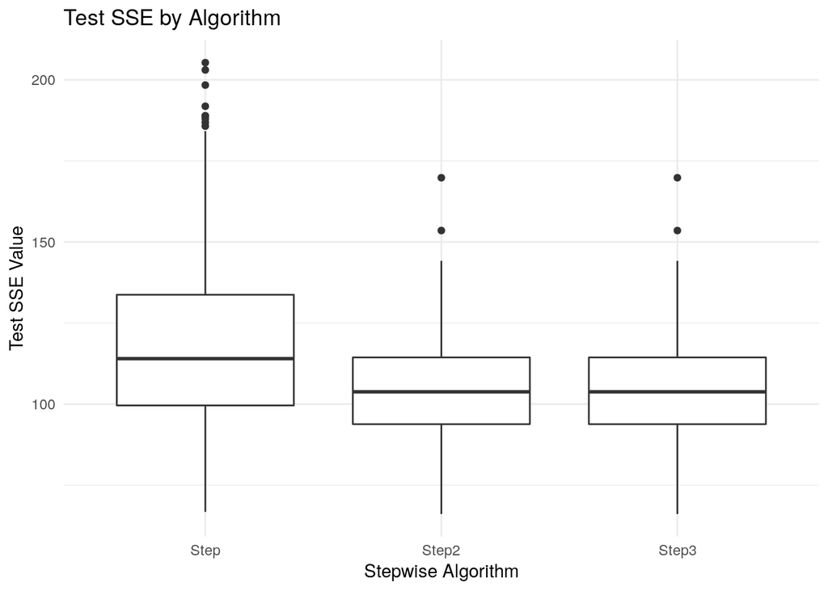

### Model 2

% Simulations that Selected Correct Model

|  | x |
| --- | --- |
| Step | 0.104 |
| Step2 | 0.159 |
| Step3 | 0.382 |

% Simulations Selected at Minimum All Correct Covariates

|  | x |
| --- | --- |
| Step | 0.134 |
| Step2 | 0.209 |
| Step3 | 0.515 |

Inclusion Order for Step, Step2, Step3 Respectively

| Order Step | # Step |
| --- | --- |
| X2 \|\| | 498 |
| X3 \|\| | 98 |
| X3 \| X1 \| X2 \|\| | 74 |
| X1 \|\| | 40 |
| X3 \| X1 \|\| | 31 |
| X2 \| X6 \|\| | 19 |
| X2 \| X9 \|\| | 19 |
| X2 \| X4 \|\| | 18 |
| X1 \| X3 \| X2 \|\| | 17 |
| X2 \| X10 \|\| | 17 |
| X2 \| X7 \|\| | 17 |
| X2 \| X5 \|\| | 15 |
| X2 \| X3 \|\| | 12 |
| X2 \| X8 \|\| | 12 |
| X2 \| X3 \| X1 \|\| | 11 |
| X3 \| X10 \|\| | 7 |
| X3 \| X1 \| X2 \| X7 \|\| | 6 |
| X3 \| X5 \|\| | 5 |
| X3 \| X7 \|\| | 5 |
| X3 \| X8 \|\| | 5 |
| X1 \| X9 \|\| | 4 |
| X3 \| X9 \|\| | 4 |
| X3 \| X6 \| X1 \| X2 \|\| | 3 |
| X1 \| X3 \|\| | 2 |
| X1 \| X4 \| X3 \| X2 \|\| | 2 |
| X1 \| X5 \|\| | 2 |
| X2 \| X1 \| X3 \|\| | 2 |
| X2 \| X10 \| X4 \|\| | 2 |
| X3 \| X1 \| X2 \| X10 \|\| | 2 |
| X3 \| X1 \| X2 \| X4 \|\| | 2 |
| X3 \| X1 \| X2 \| X6 \|\| | 2 |
| X3 \| X4 \|\| | 2 |
| X3 \| X6 \|\| | 2 |
| \|\| | 1 |
| X1 \| X10 \| X6 \| X3 \|\| | 1 |
| X1 \| X10 \|\| | 1 |
| X1 \| X3 \| X6 \| X2 \|\| | 1 |
| X1 \| X3 \| X9 \|\| | 1 |
| X1 \| X4 \|\| | 1 |
| X1 \| X6 \| X3 \|\| | 1 |
| X1 \| X6 \|\| | 1 |
| X1 \| X7 \| X5 \|\| | 1 |
| X1 \| X7 \| X8 \|\| | 1 |
| X1 \| X8 \|\| | 1 |
| X2 \| X1 \|\| | 1 |
| X2 \| X10 \| X3 \| X1 \|\| | 1 |

| Order Step2 | # Step2 |
| --- | --- |
| X2 \|\| | 498 |
| X3 \| X1X2 \|\| | 94 |
| X3 \|\| | 63 |
| X1 \| X2X3 \|\| | 32 |
| X2X3 \| X1 \|\| | 30 |
| X3 \| X1 \|\| | 26 |
| X1 \|\| | 22 |
| X2 \| X6 \|\| | 19 |
| X2 \| X9 \|\| | 19 |
| X2 \| X4 \|\| | 18 |
| X2 \| X10 \|\| | 17 |
| X2 \| X7 \|\| | 17 |
| X2 \| X5 \|\| | 14 |
| X2X3 \|\| | 13 |
| X2 \| X8 \|\| | 12 |
| X3 \| X1X2 \| X10 \|\| | 7 |
| X3 \| X1X2 \| X7 \|\| | 7 |
| X3 \| X1X2 \| X6 \|\| | 6 |
| X3 \| X1X2 \| X5 \|\| | 4 |
| X3 \| X7 \|\| | 4 |
| X3 \| X8 \|\| | 4 |
| X1X2 \| X3 \|\| | 3 |
| X3 \| X10 \|\| | 3 |
| X3 \| X5 \|\| | 3 |
| X3 \| X9 \|\| | 3 |
| X1 \| X2X3 \| X7 \|\| | 2 |
| X1 \| X3 \|\| | 2 |
| X1 \| X4 \| X2X3 \|\| | 2 |
| X1 \| X5 \|\| | 2 |
| X1 \| X9 \| X2X3 \|\| | 2 |
| X2 \| X10 \| X4 \|\| | 2 |
| X2X3 \| X1 \| X10 \|\| | 2 |
| X2X3 \| X1 \| X4 \|\| | 2 |
| X2X3 \| X7 \|\| | 2 |
| X3 \| X1X2 \| X4 \| X8 \|\| | 2 |
| X3 \| X1X2 \| X4 \|\| | 2 |
| X3 \| X1X2 \| X8 \|\| | 2 |
| X3 \| X6 \|\| | 2 |
| \|\| | 1 |
| X1 \| X10 \| X6 \| X3 \|\| | 1 |
| X1 \| X10 \|\| | 1 |
| X1 \| X2X3 \| X10 \|\| | 1 |
| X1 \| X2X3 \| X9 \|\| | 1 |
| X1 \| X3 \| X6 \| X2 \|\| | 1 |
| X1 \| X3 \| X9 \|\| | 1 |
| X1 \| X4 \|\| | 1 |

| Order Step3 | # Step3 |
| --- | --- |
| X1X2X3 \|\| | 382 |
| X2 \|\| | 271 |
| X3 \|\| | 63 |
| X1X2X3 \| X10 \|\| | 23 |
| X1X2X3 \| X7 \|\| | 23 |
| X1 \|\| | 22 |
| X1X2X3 \| X4 \|\| | 19 |
| X3 \| X1 \|\| | 18 |
| X1X2X3 \| X6 \|\| | 17 |
| X2X3 \|\| | 13 |
| X1X2X3 \| X5 \|\| | 12 |
| X1X2X3 \| X9 \|\| | 12 |
| X2 \| X10 \|\| | 10 |
| X2 \| X8 \|\| | 10 |
| X2 \| X9 \|\| | 10 |
| X2 \| X5 \|\| | 9 |
| X2 \| X6 \|\| | 9 |
| X2 \| X4 \|\| | 8 |
| X2 \| X7 \|\| | 7 |
| X1X2X3 \| X8 \|\| | 6 |
| X1X2X3 \| X4 \| X8 \|\| | 4 |
| X3 \| X7 \|\| | 4 |
| X3 \| X8 \|\| | 4 |
| X3 \| X9 \|\| | 3 |
| X1 \| X9 \| X2X3 \|\| | 2 |
| X1X2X3 \| X6 \| X5 \|\| | 2 |
| X1X2X3 \| X8 \| X4 \|\| | 2 |
| X3 \| X10 \|\| | 2 |
| \|\| | 1 |
| X1 \| X10 \|\| | 1 |
| X1 \| X3 \| X9 \|\| | 1 |
| X1 \| X3 \|\| | 1 |
| X1 \| X4 \|\| | 1 |
| X1 \| X5 \|\| | 1 |
| X1 \| X6 \| X3 \|\| | 1 |
| X1 \| X6 \|\| | 1 |
| X1 \| X7 \| X8 \|\| | 1 |
| X1 \| X8 \|\| | 1 |
| X1X2 \|\| | 1 |
| X1X2X3 \| X10 \| X4 \|\| | 1 |
| X1X2X3 \| X10 \| X5 \|\| | 1 |
| X1X2X3 \| X5 \| X4 \|\| | 1 |
| X1X2X3 \| X5 \| X7 \|\| | 1 |
| X1X2X3 \| X5 \| X9 \|\| | 1 |
| X1X2X3 \| X6 \| X10 \|\| | 1 |
| X1X2X3 \| X6 \| X9 \|\| | 1 |

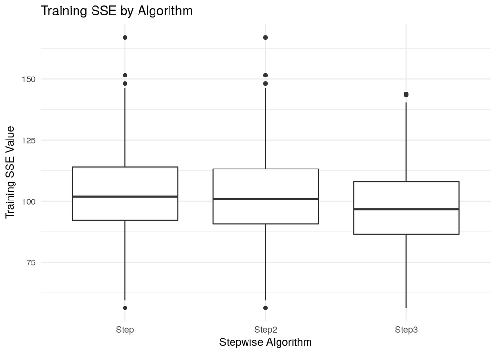

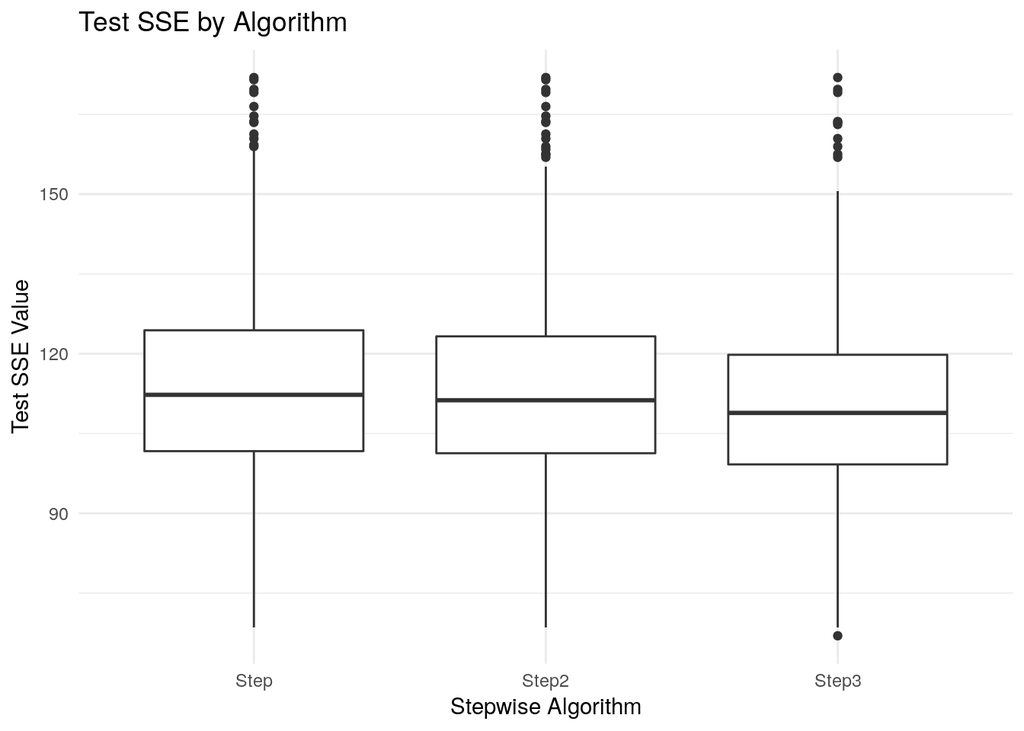

### Model 3

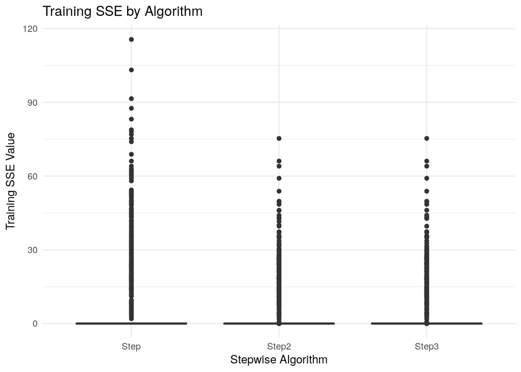

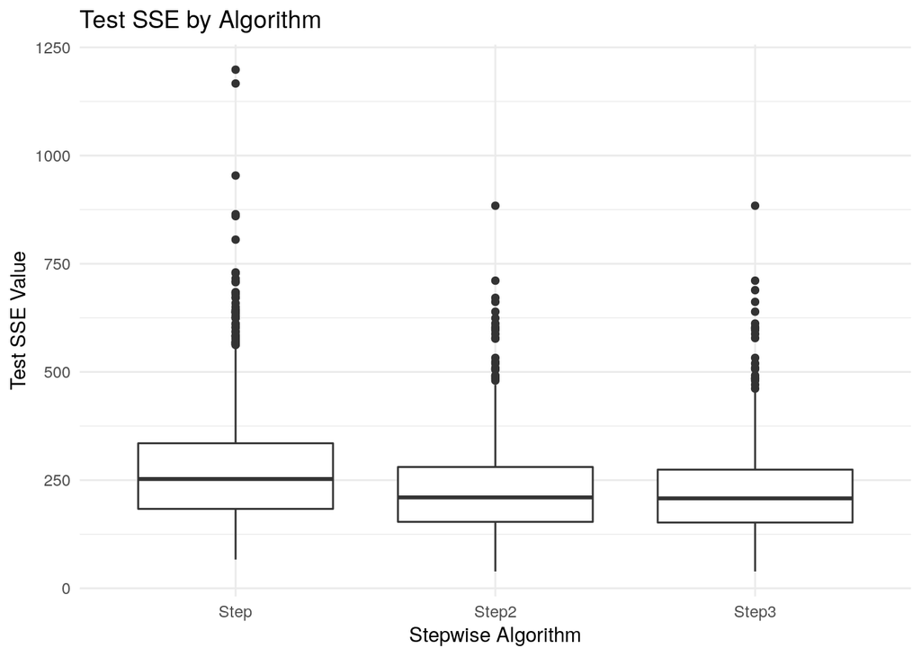

## Algorithm Source Code URL

- View source code at https://github.com/riley-ashton/Selection/tree/master/R
- View report code at https://github.com/riley-ashton/Selection-Report

# References

Hamilton, David. 1987. “Sometimes R 2> R 2 Yx 1+ R 2 Yx 2: Correlated Variables Are Not Always Redundant.” *The American Statistician* 41 (2). Taylor & Francis Group: 129–32.